# HW2_syQiu

# Exercise 2.1 Communication

See the updated .pdf, .qmd, .html.

# Exercise 2.2 Data Wrangling

## 4.2.5

Import packages and dataset

1. Single line filters

   ```r
   data("flights")
   flights |> filter(arr_delay > 120)
   ```

   ```
   # A tibble: 10,034 × 19
       year month   day dep_time sched_dep_time dep_delay arr_time sched_arr_time
      <int> <int> <int>    <int>          <int>     <dbl>    <int>          <int>
    1  2013     1     1      811            630       101     1047            830
    2  2013     1     1      848           1835       853     1001           1950
    3  2013     1     1      957            733       144     1056            853
    4  2013     1     1     1114            900       134     1447           1222
    5  2013     1     1     1505           1310       115     1638           1431
    6  2013     1     1     1525           1340       105     1831           1626
    7  2013     1     1     1549           1445        64     1912           1656
    8  2013     1     1     1558           1359       119     1718           1515
    9  2013     1     1     1732           1630        62     2028           1825
   10  2013     1     1     1803           1620       103     2008           1750
   # ℹ 10,024 more rows
   # ℹ 11 more variables: arr_delay <dbl>, carrier <chr>, flight <int>,
   #   tailnum <chr>, origin <chr>, dest <chr>, air_time <dbl>, distance <dbl>,
   #   hour <dbl>, minute <dbl>, time_hour <dttm>
   ```

   ```r
   flights |> filter(dest %in% c("IAH","HOU"))
   ```

   ```
   # A tibble: 9,313 × 19
       year month   day dep_time sched_dep_time dep_delay arr_time sched_arr_time
      <int> <int> <int>    <int>          <int>     <dbl>    <int>          <int>
    1  2013     1     1      517            515         2      830            819
    2  2013     1     1      533            529         4      850            830
    3  2013     1     1      623            627        -4      933            932
    4  2013     1     1      728            732        -4     1041           1038
    5  2013     1     1      739            739         0     1104           1038
    6  2013     1     1      908            908         0     1228           1219
    7  2013     1     1     1028           1026         2     1350           1339
    8  2013     1     1     1044           1045        -1     1352           1351
    9  2013     1     1     1114            900       134     1447           1222
   10  2013     1     1     1205           1200         5     1503           1505
   # ℹ 9,303 more rows
   # ℹ 11 more variables: arr_delay <dbl>, carrier <chr>, flight <int>,
   #   tailnum <chr>, origin <chr>, dest <chr>, air_time <dbl>, distance <dbl>,
   #   hour <dbl>, minute <dbl>, time_hour <dttm>
   ```

   ```r
   flights |> filter(carrier %in% c("UA","DL","AA"))
   ```

   ```
   # A tibble: 139,504 × 19
       year month   day dep_time sched_dep_time dep_delay arr_time sched_arr_time
      <int> <int> <int>    <int>          <int>     <dbl>    <int>          <int>
    1  2013     1     1      517            515         2      830            819
    2  2013     1     1      533            529         4      850            830
    3  2013     1     1      542            540         2      923            850
    4  2013     1     1      554            600        -6      812            837
    5  2013     1     1      554            558        -4      740            728
    6  2013     1     1      558            600        -2      753            745
    7  2013     1     1      558            600        -2      924            917
    8  2013     1     1      558            600        -2      923            937
    9  2013     1     1      559            600        -1      941            910
   10  2013     1     1      559            600        -1      854            902
   # ℹ 139,494 more rows
   # ℹ 11 more variables: arr_delay <dbl>, carrier <chr>, flight <int>,
   #   tailnum <chr>, origin <chr>, dest <chr>, air_time <dbl>, distance <dbl>,
   #   hour <dbl>, minute <dbl>, time_hour <dttm>
   ```

   ```r
   flights |> filter(month >= 7 & month <= 9)
   ```

   ```
   # A tibble: 86,326 × 19
       year month   day dep_time sched_dep_time dep_delay arr_time sched_arr_time
      <int> <int> <int>    <int>          <int>     <dbl>    <int>          <int>
    1  2013     7     1        1           2029       212      236           2359
    2  2013     7     1        2           2359         3      344            344
    3  2013     7     1       29           2245       104      151              1
    4  2013     7     1       43           2130       193      322             14
    5  2013     7     1       44           2150       174      300            100
    6  2013     7     1       46           2051       235      304           2358
    7  2013     7     1       48           2001       287      308           2305
    8  2013     7     1       58           2155       183      335             43
    9  2013     7     1      100           2146       194      327             30
   10  2013     7     1      100           2245       135      337            135
   # ℹ 86,316 more rows
   # ℹ 11 more variables: arr_delay <dbl>, carrier <chr>, flight <int>,
   #   tailnum <chr>, origin <chr>, dest <chr>, air_time <dbl>, distance <dbl>,
   #   hour <dbl>, minute <dbl>, time_hour <dttm>
   ```

   ```r
   flights |> filter(dep_delay <= 0 & arr_delay > 120)
   ```

   ```
   # A tibble: 29 × 19
       year month   day dep_time sched_dep_time dep_delay arr_time sched_arr_time
      <int> <int> <int>    <int>          <int>     <dbl>    <int>          <int>
    1  2013     1    27     1419           1420        -1     1754           1550
    2  2013    10     7     1350           1350         0     1736           1526
    3  2013    10     7     1357           1359        -2     1858           1654
    4  2013    10    16      657            700        -3     1258           1056
    5  2013    11     1      658            700        -2     1329           1015
    6  2013     3    18     1844           1847        -3       39           2219
    7  2013     4    17     1635           1640        -5     2049           1845
    8  2013     4    18      558            600        -2     1149            850
    9  2013     4    18      655            700        -5     1213            950
   10  2013     5    22     1827           1830        -3     2217           2010
   # ℹ 19 more rows
   # ℹ 11 more variables: arr_delay <dbl>, carrier <chr>, flight <int>,
   #   tailnum <chr>, origin <chr>, dest <chr>, air_time <dbl>, distance <dbl>,
   #   hour <dbl>, minute <dbl>, time_hour <dttm>
   ```

   ```r
   flights |> filter(dep_delay >= 60 & arr_delay <= 30)
   ```

   ```
   # A tibble: 239 × 19
       year month   day dep_time sched_dep_time dep_delay arr_time sched_arr_time
      <int> <int> <int>    <int>          <int>     <dbl>    <int>          <int>
    1  2013     1     3     1850           1745        65     2148           2120
    2  2013     1     3     1950           1845        65     2228           2227
    3  2013     1     3     2015           1915        60     2135           2111
    4  2013     1     6     1019            900        79     1558           1530
    5  2013     1     7     1543           1430        73     1758           1735
    6  2013     1    11     1020            920        60     1311           1245
    7  2013     1    12     1706           1600        66     1949           1927
    8  2013     1    12     1953           1845        68     2154           2137
    9  2013     1    19     1456           1355        61     1636           1615
   10  2013     1    21     1531           1430        61     1843           1815
   # ℹ 229 more rows
   # ℹ 11 more variables: arr_delay <dbl>, carrier <chr>, flight <int>,
   #   tailnum <chr>, origin <chr>, dest <chr>, air_time <dbl>, distance <dbl>,
   #   hour <dbl>, minute <dbl>, time_hour <dttm>
   ```

2. Longest departure delays and earliest departure

   ```r
   flights |>
     arrange(desc(dep_delay))
   ```

   ```
   # A tibble: 336,776 × 19
       year month   day dep_time sched_dep_time dep_delay arr_time sched_arr_time
      <int> <int> <int>    <int>          <int>     <dbl>    <int>          <int>
    1  2013     1     9      641            900      1301     1242           1530
    2  2013     6    15     1432           1935      1137     1607           2120
    3  2013     1    10     1121           1635      1126     1239           1810
    4  2013     9    20     1139           1845      1014     1457           2210
    5  2013     7    22      845           1600      1005     1044           1815
    6  2013     4    10     1100           1900       960     1342           2211
    7  2013     3    17     2321            810       911      135           1020
    8  2013     6    27      959           1900       899     1236           2226
    9  2013     7    22     2257            759       898      121           1026
   10  2013    12     5      756           1700       896     1058           2020
   # ℹ 336,766 more rows
   # ℹ 11 more variables: arr_delay <dbl>, carrier <chr>, flight <int>,
   #   tailnum <chr>, origin <chr>, dest <chr>, air_time <dbl>, distance <dbl>,
   #   hour <dbl>, minute <dbl>, time_hour <dttm>
   ```

   ```r
   flights |>
     filter(dep_time > 0 & dep_time < 1200) |>
     arrange(dep_time)
   ```

   ```
   # A tibble: 131,023 × 19
       year month   day dep_time sched_dep_time dep_delay arr_time sched_arr_time
      <int> <int> <int>    <int>          <int>     <dbl>    <int>          <int>
    1  2013     1    13        1           2249        72      108           2357
    2  2013     1    31        1           2100       181      124           2225
    3  2013    11    13        1           2359         2      442            440
    4  2013    12    16        1           2359         2      447            437
    5  2013    12    20        1           2359         2      430            440
    6  2013    12    26        1           2359         2      437            440
    7  2013    12    30        1           2359         2      441            437
    8  2013     2    11        1           2100       181      111           2225
    9  2013     2    24        1           2245        76      121           2354
   10  2013     3     8        1           2355         6      431            440
   # ℹ 131,013 more rows
   # ℹ 11 more variables: arr_delay <dbl>, carrier <chr>, flight <int>,
   #   tailnum <chr>, origin <chr>, dest <chr>, air_time <dbl>, distance <dbl>,
   #   hour <dbl>, minute <dbl>, time_hour <dttm>
   ```

   Use `arrange()` and `filter()`, we can see the longest delay time was 1301 minutes. The flights left earliest in the morning at 00:01 AM.

   Another way to do this without using `arrange()` and `filter()`:

   ```r
   flights |> filter(dep_delay == max(dep_delay, na.rm = TRUE))
   ```

   ```
   # A tibble: 1 × 19
      year month   day dep_time sched_dep_time dep_delay arr_time sched_arr_time
     <int> <int> <int>    <int>          <int>     <dbl>    <int>          <int>
   1  2013     1     9      641            900      1301     1242           1530
   # ℹ 11 more variables: arr_delay <dbl>, carrier <chr>, flight <int>,
   #   tailnum <chr>, origin <chr>, dest <chr>, air_time <dbl>, distance <dbl>,
   #   hour <dbl>, minute <dbl>, time_hour <dttm>
   ```

   ```r
   flights |> filter(dep_time > 0 & dep_time < 1200 & dep_time == min(dep_time, na.rm = TRUE))
   ```

   ```
   # A tibble: 25 × 19
       year month   day dep_time sched_dep_time dep_delay arr_time sched_arr_time
      <int> <int> <int>    <int>          <int>     <dbl>    <int>          <int>
    1  2013     1    13        1           2249        72      108           2357
    2  2013     1    31        1           2100       181      124           2225
    3  2013    11    13        1           2359         2      442            440
    4  2013    12    16        1           2359         2      447            437
    5  2013    12    20        1           2359         2      430            440
    6  2013    12    26        1           2359         2      437            440
    7  2013    12    30        1           2359         2      441            437
    8  2013     2    11        1           2100       181      111           2225
    9  2013     2    24        1           2245        76      121           2354
   10  2013     3     8        1           2355         6      431            440
   # ℹ 15 more rows
   # ℹ 11 more variables: arr_delay <dbl>, carrier <chr>, flight <int>,
   #   tailnum <chr>, origin <chr>, dest <chr>, air_time <dbl>, distance <dbl>,
   #   hour <dbl>, minute <dbl>, time_hour <dttm>
   ```

3. Fastest flights

   ```r
   flights |> arrange(desc(distance/air_time))
   ```

   ```
   # A tibble: 336,776 × 19
       year month   day dep_time sched_dep_time dep_delay arr_time sched_arr_time
      <int> <int> <int>    <int>          <int>     <dbl>    <int>          <int>
    1  2013     5    25     1709           1700         9     1923           1937
    2  2013     7     2     1558           1513        45     1745           1719
    3  2013     5    13     2040           2025        15     2225           2226
    4  2013     3    23     1914           1910         4     2045           2043
    5  2013     1    12     1559           1600        -1     1849           1917
    6  2013    11    17      650            655        -5     1059           1150
    7  2013     2    21     2355           2358        -3      412            438
    8  2013    11    17      759            800        -1     1212           1255
    9  2013    11    16     2003           1925        38       17             36
   10  2013    11    16     2349           2359       -10      402            440
   # ℹ 336,766 more rows
   # ℹ 11 more variables: arr_delay <dbl>, carrier <chr>, flight <int>,
   #   tailnum <chr>, origin <chr>, dest <chr>, air_time <dbl>, distance <dbl>,
   #   hour <dbl>, minute <dbl>, time_hour <dttm>
   ```

   The fastest flights in 2013 was the flight from LGA to ATL on May 25th departed at 17:09 PM. It traveled at a speed rate of 11.72 miles per minute.
4. Daily flight in 2013?

   ```r
   flights |>
     filter(year == 2013) |>
     distinct(month, day) |>
     count()
   ```

   ```
   # A tibble: 1 × 1
         n
     <int>
   1   365
   ```

   There was flight on all 365 days of 2013.
5. Farthest distance, least distance

   ```r
   flights |> arrange(desc(distance)) |> filter(row_number() == 1)
   ```

   ```
   # A tibble: 1 × 19
      year month   day dep_time sched_dep_time dep_delay arr_time sched_arr_time
     <int> <int> <int>    <int>          <int>     <dbl>    <int>          <int>
   1  2013     1     1      857            900        -3     1516           1530
   # ℹ 11 more variables: arr_delay <dbl>, carrier <chr>, flight <int>,
   #   tailnum <chr>, origin <chr>, dest <chr>, air_time <dbl>, distance <dbl>,
   #   hour <dbl>, minute <dbl>, time_hour <dttm>
   ```

   ```r
   flights |> arrange(distance) |> filter(row_number() == 1)
   ```

   ```
   # A tibble: 1 × 19
      year month   day dep_time sched_dep_time dep_delay arr_time sched_arr_time
     <int> <int> <int>    <int>          <int>     <dbl>    <int>          <int>
   1  2013     7    27       NA            106        NA       NA            245
   # ℹ 11 more variables: arr_delay <dbl>, carrier <chr>, flight <int>,
   #   tailnum <chr>, origin <chr>, dest <chr>, air_time <dbl>, distance <dbl>,
   #   hour <dbl>, minute <dbl>, time_hour <dttm>
   ```

   Flights from JFK to HNL traveled the farthest distance of 4983 miles. Flights from EWR to LGA traveled the shorted distance of only 17 miles.
6. The order of `filter()` and `order()` does not matter as for the results because the value for sorting does not change by either function. However, `filter()` before `order()` could speed up the operation of the code because R would have fewer observations to sort after subset.

## 4.3.5

1. `dep_time`, `sched_dep_time`, and `dep_delay`

   ```r
   flights |>
     select(dep_time, sched_dep_time, dep_delay)
   ```

   ```
   # A tibble: 336,776 × 3
      dep_time sched_dep_time dep_delay
         <int>          <int>     <dbl>
    1      517            515         2
    2      533            529         4
    3      542            540         2
    4      544            545        -1
    5      554            600        -6
    6      554            558        -4
    7      555            600        -5
    8      557            600        -3
    9      557            600        -3
   10      558            600        -2
   # ℹ 336,766 more rows
   ```

   ```r
   flights |>
     mutate(dep_delay_verify = (dep_time %/% 100 - sched_dep_time %/% 100) * 60 + (dep_time %% 100 - sched_dep_time %% 100)) |>
     select(dep_time, sched_dep_time, dep_delay, dep_delay_verify) |>
     mutate(if_equals = dep_delay == dep_delay_verify) |>
     count(if_equals)
   ```

   ```
   # A tibble: 3 × 2
     if_equals      n
     <lgl>      <int>
   1 FALSE       1207
   2 TRUE      327314
   3 NA          8255
   ```

   `dep_delay` is the difference between `dep_time` and `sched_dep_time`. However in the `flights` dataset, `dep_time` and `sched_dep_time` are presented as `hm` without column in-between. Therefore, the exact equation to compute should be `(dep_time %/% 100 - sched_dep_time %/% 100) * 60 + (dep_time %% 100 - sched_dep_time %% 100)` if the scheduled time of departure and the actual time of departure was on the same day. For delay across two days (n = 1207), `dep_delay` equals to `(dep_time %/% 100 - sched_dep_time %/% 100) * 60 + (dep_time %% 100 - sched_dep_time %% 100) + 24*60`
2. Subset!

   ```r
   flights |> select(dep_time, dep_delay, arr_time, arr_delay) # Directly specify
   ```

   ```
   # A tibble: 336,776 × 4
      dep_time dep_delay arr_time arr_delay
         <int>     <dbl>    <int>     <dbl>
    1      517         2      830        11
    2      533         4      850        20
    3      542         2      923        33
    4      544        -1     1004       -18
    5      554        -6      812       -25
    6      554        -4      740        12
    7      555        -5      913        19
    8      557        -3      709       -14
    9      557        -3      838        -8
   10      558        -2      753         8
   # ℹ 336,766 more rows
   ```

   ```r
   flights |> select(starts_with("dep"),starts_with("arr")) # use starts_with()
   ```

   ```
   # A tibble: 336,776 × 4
      dep_time dep_delay arr_time arr_delay
         <int>     <dbl>    <int>     <dbl>
    1      517         2      830        11
    2      533         4      850        20
    3      542         2      923        33
    4      544        -1     1004       -18
    5      554        -6      812       -25
    6      554        -4      740        12
    7      555        -5      913        19
    8      557        -3      709       -14
    9      557        -3      838        -8
   10      558        -2      753         8
   # ℹ 336,766 more rows
   ```

   ```r
   flights |> select(starts_with(c("arr","dep"))) # another way to use starts_with() but combine together
   ```

   ```
   # A tibble: 336,776 × 4
      arr_time arr_delay dep_time dep_delay
         <int>     <dbl>    <int>     <dbl>
    1      830        11      517         2
    2      850        20      533         4
    3      923        33      542         2
    4     1004       -18      544        -1
    5      812       -25      554        -6
    6      740        12      554        -4
    7      913        19      555        -5
    8      709       -14      557        -3
    9      838        -8      557        -3
   10      753         8      558        -2
   # ℹ 336,766 more rows
   ```

   ```r
   flights |> select(ends_with(c("time","delay")) & starts_with(c("arr","dep"))) # use ends_with()
   ```

   ```
   # A tibble: 336,776 × 4
      dep_time arr_time dep_delay arr_delay
         <int>    <int>     <dbl>     <dbl>
    1      517      830         2        11
    2      533      850         4        20
    3      542      923         2        33
    4      544     1004        -1       -18
    5      554      812        -6       -25
    6      554      740        -4        12
    7      555      913        -5        19
    8      557      709        -3       -14
    9      557      838        -3        -8
   10      558      753        -2         8
   # ℹ 336,766 more rows
   ```

3. Duplicated specification in `select()`

   ```r
   flights |> select(dep_delay, dep_delay, arr_delay)
   ```

   ```
   # A tibble: 336,776 × 2
      dep_delay arr_delay
          <dbl>     <dbl>
    1         2        11
    2         4        20
    3         2        33
    4        -1       -18
    5        -6       -25
    6        -4        12
    7        -5        19
    8        -3       -14
    9        -3        -8
   10        -2         8
   # ℹ 336,766 more rows
   ```

   It will only show the column for once even though the code specifies twice.
4. `any_of()`

   ```r
   variables <- c("year", "month", "day", "dep_delay", "arr_delay")
   flights |> select(any_of(variables))
   ```

   ```
   # A tibble: 336,776 × 5
       year month   day dep_delay arr_delay
      <int> <int> <int>     <dbl>     <dbl>
    1  2013     1     1         2        11
    2  2013     1     1         4        20
    3  2013     1     1         2        33
    4  2013     1     1        -1       -18
    5  2013     1     1        -6       -25
    6  2013     1     1        -4        12
    7  2013     1     1        -5        19
    8  2013     1     1        -3       -14
    9  2013     1     1        -3        -8
   10  2013     1     1        -2         8
   # ℹ 336,766 more rows
   ```

   ```r
   flights |> select(contains("TIME"))
   ```

   ```
   # A tibble: 336,776 × 6
      dep_time sched_dep_time arr_time sched_arr_time air_time time_hour
         <int>          <int>    <int>          <int>    <dbl> <dttm>
    1      517            515      830            819      227 2013-01-01 05:00:00
    2      533            529      850            830      227 2013-01-01 05:00:00
    3      542            540      923            850      160 2013-01-01 05:00:00
    4      544            545     1004           1022      183 2013-01-01 05:00:00
    5      554            600      812            837      116 2013-01-01 06:00:00
    6      554            558      740            728      150 2013-01-01 05:00:00
    7      555            600      913            854      158 2013-01-01 06:00:00
    8      557            600      709            723       53 2013-01-01 06:00:00
    9      557            600      838            846      140 2013-01-01 06:00:00
   10      558            600      753            745      138 2013-01-01 06:00:00
   # ℹ 336,766 more rows
   ```

   ```r
   flights |> select(contains("TIME", ignore.case = FALSE))
   ```

   ```
   # A tibble: 336,776 × 0
   ```

   The code `flights |> select(contains("TIME"))` returns an output with all the variables containing the character “time”, no matter whether they are lower case or upper case.

   The helper of `select()`shows that we can solve this issue by change the value of `ignore.case` option. When I changed the value of `ignore.case` to `FALSE`, no columns were returned.
6. Rename and relocate

   ```r
   flights |>
     rename(air_time_min = air_time) |>
     relocate(air_time_min, .before = 1)
   ```

   ```
   # A tibble: 336,776 × 19
      air_time_min  year month   day dep_time sched_dep_time dep_delay arr_time
             <dbl> <int> <int> <int>    <int>          <int>     <dbl>    <int>
    1          227  2013     1     1      517            515         2      830
    2          227  2013     1     1      533            529         4      850
    3          160  2013     1     1      542            540         2      923
    4          183  2013     1     1      544            545        -1     1004
    5          116  2013     1     1      554            600        -6      812
    6          150  2013     1     1      554            558        -4      740
    7          158  2013     1     1      555            600        -5      913
    8           53  2013     1     1      557            600        -3      709
    9          140  2013     1     1      557            600        -3      838
   10          138  2013     1     1      558            600        -2      753
   # ℹ 336,766 more rows
   # ℹ 11 more variables: sched_arr_time <int>, arr_delay <dbl>, carrier <chr>,
   #   flight <int>, tailnum <chr>, origin <chr>, dest <chr>, distance <dbl>,
   #   hour <dbl>, minute <dbl>, time_hour <dttm>
   ```

7. Debug

   The current code select only `tailnum` from the data frame. Therefore, the data that it passed to `arrange()` function is only a one-column data frame of `tailnum`. To correct this, it should also include `arr_delay` in the `select()` function.

   ```r
   flights |>
     select(tailnum, arr_delay) |>
     arrange(arr_delay)
   ```

   ```
   # A tibble: 336,776 × 2
      tailnum arr_delay
      <chr>       <dbl>
    1 N843VA        -86
    2 N840VA        -79
    3 N851UA        -75
    4 N3KCAA        -75
    5 N551AS        -74
    6 N24212        -73
    7 N3760C        -71
    8 N806UA        -71
    9 N805JB        -71
   10 N855VA        -70
   # ℹ 336,766 more rows
   ```

## 4.5.7

1. Delays

   ```r
   flights |>
     group_by(carrier) |>
     summarise(
       avg_delay = mean(dep_delay, na.rm = TRUE),
       n = n()
     ) |>
     arrange(desc(n))
   ```

   ```
   # A tibble: 16 × 3
      carrier avg_delay     n
      <chr>       <dbl> <int>
    1 UA          12.1  58665
    2 B6          13.0  54635
    3 EV          20.0  54173
    4 DL           9.26 48110
    5 AA           8.59 32729
    6 MQ          10.6  26397
    7 US           3.78 20536
    8 9E          16.7  18460
    9 WN          17.7  12275
   10 VX          12.9   5162
   11 FL          18.7   3260
   12 AS           5.80   714
   13 F9          20.2    685
   14 YV          19.0    601
   15 HA           4.90   342
   16 OO          12.6     32
   ```

   ```r
   flights |>
     group_by(carrier, dest) |>
     summarise(
       avg_delay = mean(dep_delay, na.rm = TRUE),
       n = n()
     ) |>
     arrange(desc(n))
   ```

   ```
   # A tibble: 314 × 4
   # Groups:   carrier [16]
      carrier dest  avg_delay     n
      <chr>   <chr>     <dbl> <int>
    1 DL      ATL       10.4  10571
    2 US      CLT        4.33  8632
    3 AA      DFW        7.49  7257
    4 AA      MIA        7.17  7234
    5 UA      ORD       14.0   6984
    6 UA      IAH       10.7   6924
    7 UA      SFO       12.0   6819
    8 B6      FLL       14.6   6563
    9 B6      MCO       14.9   6472
   10 AA      ORD        9.32  6059
   # ℹ 304 more rows
   ```

   ```r
   flights |>
     group_by(dest) |>
     slice_max(dep_delay, with_ties = TRUE) |>
     relocate(dest, dep_delay, .before = 1)
   ```

   ```
   # A tibble: 105 × 19
   # Groups:   dest [105]
      dest  dep_delay  year month   day dep_time sched_dep_time arr_time
      <chr>     <dbl> <int> <int> <int>    <int>          <int>    <int>
    1 ABQ         142  2013    12    14     2223           2001      133
    2 ACK         219  2013     7    23     1139            800     1250
    3 ALB         323  2013     1    25      123           2000      229
    4 ANC          75  2013     8    17     1740           1625     2042
    5 ATL         898  2013     7    22     2257            759      121
    6 AUS         351  2013     7    10     2056           1505     2347
    7 AVL         222  2013     6    14     1158            816     1335
    8 BDL         252  2013     2    21     1728           1316     1839
    9 BGR         248  2013    12     1     1504           1056     1628
   10 BHM         325  2013     4    10       25           1900      136
   # ℹ 95 more rows
   # ℹ 11 more variables: sched_arr_time <int>, arr_delay <dbl>, carrier <chr>,
   #   flight <int>, tailnum <chr>, origin <chr>, air_time <dbl>, distance <dbl>,
   #   hour <dbl>, minute <dbl>, time_hour <dttm>
   ```

3. Delays over the course of the day

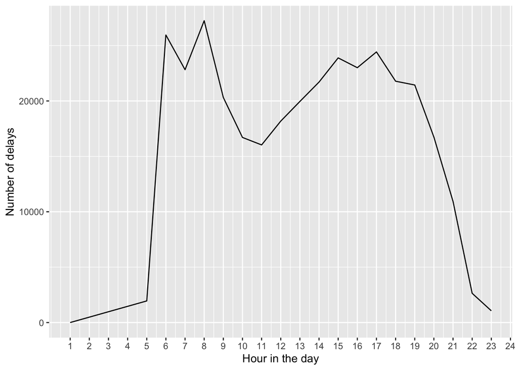

   ```r
   flights |>
     group_by(hour) |>
     summarise(
       delay_num = n()
     ) |>
     ggplot(aes(x = hour, y = delay_num)) +
     geom_line() +
     ylab("Number of delays") +
     scale_x_continuous(name = "Hour in the day", breaks = c(1:24), labels = c(1:24))
   ```

   ```r
   flights |>
     group_by(carrier) |>
     slice_max(dep_delay, n = 1)
   ```

   ```
   # A tibble: 16 × 19
   # Groups:   carrier [16]
       year month   day dep_time sched_dep_time dep_delay arr_time sched_arr_time
      <int> <int> <int>    <int>          <int>     <dbl>    <int>          <int>
    1  2013     2    16      757           1930       747     1013           2149
    2  2013     9    20     1139           1845      1014     1457           2210
    3  2013     5    23     2205           1820       225       41           2133
    4  2013     1    16     1622            800       502     1911           1054
    5  2013     4    10     1100           1900       960     1342           2211
    6  2013    12     5     1955           1047       548     2143           1245
    7  2013     2    10     2243            830       853      100           1106
    8  2013     9    12       12           1410       602      207           1635
    9  2013     1     9      641            900      1301     1242           1530
   10  2013     6    15     1432           1935      1137     1607           2120
   11  2013     8    28     2039           1805       154     2213           1953
   12  2013     7    26     2345           1542       483      104           1729
   13  2013     6    28      125           1705       500      316           1911
   14  2013     7     7     2123           1030       653       17           1345
   15  2013     5    11     2316           1525       471       43           1710
   16  2013    10    22     1812           1145       387     2017           1356
   # ℹ 11 more variables: arr_delay <dbl>, carrier <chr>, flight <int>,
   #   tailnum <chr>, origin <chr>, dest <chr>, air_time <dbl>, distance <dbl>,
   #   hour <dbl>, minute <dbl>, time_hour <dttm>
   ```

   ```r
   A <- flights |>
     slice_max(dep_delay, n = -1)

   B <- flights |>
     arrange(desc(dep_delay))

   identical(A, B)
   ```

   ```
   [1] TRUE
   ```

   ```r
   C <- flights |>
     slice_min(dep_delay, n = -1)

   D <- flights |>
     arrange(dep_delay)

   identical(C, D)
   ```

   ```
   [1] TRUE
   ```

   If I pass a negative number to the `n` option in `slice_min()` or `slice_max()` it will arrange the data frame in ascending order or descending order and give the whole arranged data frame as the output.
5. `count()`

   ```r
   flights |>
     count(carrier, sort = TRUE)
   ```

   ```
   # A tibble: 16 × 2
      carrier     n
      <chr>   <int>
    1 UA      58665
    2 B6      54635
    3 EV      54173
    4 DL      48110
    5 AA      32729
    6 MQ      26397
    7 US      20536
    8 9E      18460
    9 WN      12275
   10 VX       5162
   11 FL       3260
   12 AS        714
   13 F9        685
   14 YV        601
   15 HA        342
   16 OO         32
   ```

   `count()` does the job of grouping the data frame by the variable it got in the parenthesis and then count the number of the observations within each group. `sort` argument will arrange the generated output by the number count in a descending order.
6. Tiny data frame

```r
df <- tibble(
  x = 1:5,
  y = c("a","b","a","a","b"),
  z = c("K","K","L","L","K")
)
```

a. With only `group_by()` function, it will not change anything on the dataset.

```r
df |>
  group_by(y)
```

```
# A tibble: 5 × 3
# Groups:   y [2]
      x y     z
  <int> <chr> <chr>
1     1 a     K
2     2 b     K
3     3 a     L
4     4 a     L
5     5 b     K
```

The output shows no change after `group_by()`, as I thought. However, there is a line at the top of the output showing that the dataset has been grouped by variable `y` .

b. `arrange()` will re-order the dataset by the value of variable `y`. As `y` is a character variable, it will be ordered following a, b, c, d, …

```r
df |> arrange(y)
```

```
# A tibble: 5 × 3
      x y     z
  <int> <chr> <chr>
1     1 a     K
2     3 a     L
3     4 a     L
4     2 b     K
5     5 b     K
```

Exactly the same what I guess! `arrange()` function changes the order that the dataset presents, but it does not group the dataset as what `group_by()` does. The output shows that the dataset is not grouped.

c. This will calculate the mean of variable `x` for each group by `y`

```r
df |>
  group_by(y) |>
  summarise(mean_x = mean(x))
```

```
# A tibble: 2 × 2
  y     mean_x
  <chr>  <dbl>
1 a       2.67
2 b       3.5
```

Same as expected! The pipeline first groups the dataset by the value of `y` (into two group `a` and `b` ), and then for each group (where `y == a` and `y == b` ), it calculate the mean of `x`.

d. This calculates the mean of `x` for each group by `y` and `z`

```r
df |>
  group_by(y, z) |>
  summarise(mean_x = mean(x))
```

[output not shown]

```
# A tibble: 3 × 3
# Groups:   y [2]
  y     z     mean_x
  <chr> <chr>  <dbl>
1 a     K        1
2 a     L        3.5
3 b     K        3.5
```

e. This will do the same thing as d, but the grouping will be dropped.

```r
df |>
  group_by(y, z) |>
  summarise(mean_x = mean(x), .groups = "drop")
```

```
# A tibble: 3 × 3
  y     z     mean_x
  <chr> <chr>  <dbl>
1 a     K        1
2 a     L        3.5
3 b     K        3.5
```

We can see that this tibble is no longer grouped by `y`.

f. The first pipelines calculates the mean of x by grouping over `y` and `z`, which will only keep the distinct lines for each group and will only keep the grouping indicator and the summary statistics. The second pipelines however, will calculates the group mean of which each observation belongs to and make it an additional value for each observation.

```r
df |>
  group_by(y, z) |>
  summarise(mean_x = mean(x))
```

[output not shown]

```
# A tibble: 3 × 3
# Groups:   y [2]
  y     z     mean_x
  <chr> <chr>  <dbl>
1 a     K        1
2 a     L        3.5
3 b     K        3.5
```

```r
df |>
  group_by(y, z) |>
  mutate(mean_x = mean(x))
```

```
# A tibble: 5 × 4
# Groups:   y, z [3]
      x y     z     mean_x
  <int> <chr> <chr>  <dbl>
1     1 a     K        1
2     2 b     K        3.5
3     3 a     L        3.5
4     4 a     L        3.5
5     5 b     K        3.5
```

The output are as expected. One thing to notice is that the second one created by `mutate()` are grouped by `y` and `z`, while the one created by `summarise()` is only grouped by `y`.